### Test a Perceptual Phenomenon - Stroop Effect

M Jamal Khan - December 30, 2017

### Background Information

In a Stroop task, participants are presented with a list of words, with each word displayed in a color of ink. The participant’s task is to say out loud the color of the ink in which the word is printed. The task has two conditions: a congruent words condition, and an incongruent words condition. In the congruent words condition, the words being displayed are color words whose names match the colors in which they are printed: for example RED, BLUE. In the incongruent words condition, the words displayed are color words whose names do not match the colors in which they are printed: for example PURPLE, ORANGE. In each case, we measure the time it takes to name the ink colors in equally-sized lists. Each participant will go through and record a time from each condition.

### 1. What is our independent variable? What is our dependent variable?

INDEPENDENT - The name of the color matches with ink color (Congruent or Incongruent)

DEPENDENT - Response Time in seconds

### 2. What is an appropriate set of hypotheses for this task? What kind of statistical test do you expect to perform? Justify your choices.

Ho - Null Hypothesis: (MU(i) - MU(c) = 0) There is no significant difference in the population average response time in viewing the congruent(c) words vs viewing incongruent(i) words.

Ha - Alternative Hypothesis: (MU(i) - MU(c) != 0). There is a significant difference, positive or negative, in the population average response times.

Assuming that the population data is approximately normally distributed, and for the reasons listed below, we expect to perform a two sample Paired t-test, which is carried out when two different treatments are applied to the same index. 1. The variance/standard deviation of the population is unknown. 2. Sample size is less than 30.(Here n=24 <30)

Since we don’t have any population parameters in the stroop sample, so a z-test would not be appropriate here.

### 3. Report some descriptive statistics regarding this dataset. Include at least one measure of central tendency and at least one measure of variability.

```
## # A tibble: 2 x 5
##    congruency `mean(time)` `median(time)` `sd(time)` `var(time)`
##         <chr>        <dbl>          <dbl>      <dbl>       <dbl>
## 1   Congruent     14.05113        14.3565   3.559358    12.66903
## 2 Incongruent     22.01592        21.0175   4.797057    23.01176
```

### 4. Provide one or two visualizations that show the distribution of the sample data. Write one or two sentences noting what you observe about the plot or plots.

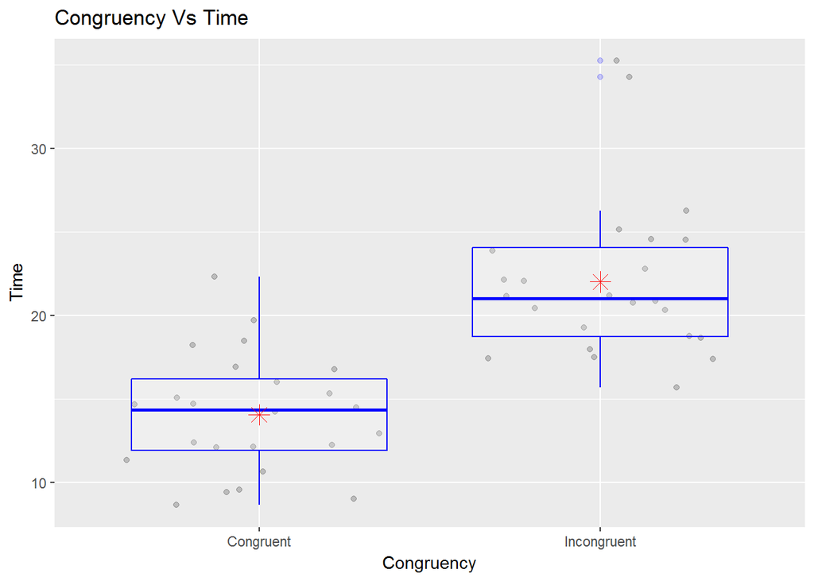

The boxplot indicates that the two groups (congruent & incongruent) have significant difference in median, and also have different ranges - with the Incongruent words group presenting much longer times.

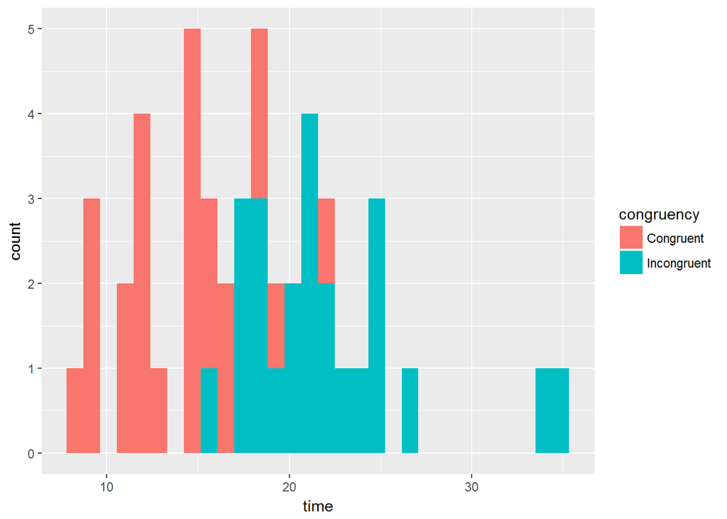

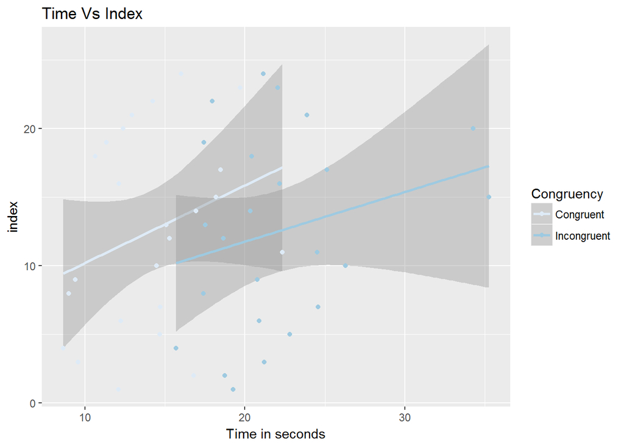

### 5. Now, perform the statistical test and report your results. What is your confidence level and your critical statistic value? Do you reject the null hypothesis or fail to reject it? Come to a conclusion in terms of the experiment task. Did the results match up with your expectations?

```
## [1] -8.020707
```

```
##
##  Paired t-test
##
## data:  stroop_dataframe$Congruent and stroop_dataframe$Incongruent
## t = -8.0207, df = 23, p-value = 4.103e-08
## alternative hypothesis: true difference in means is not equal to 0
## 95 percent confidence interval:
##  -10.019028  -5.910555
## sample estimates:
## mean of the differences
##               -7.964792
```

### References

https://blog.rstudio.com/2014/07/22/introducing-tidyr/  
https://faculty.washington.edu/chudler/java/timesc.html  
R Help